# Ex: Capital Market

# Brief

This RMD file is prepared for homework assignment for a class. I will introduce the situation, the goal, and audience to make the story vivid for my reader.

Back to top

# Story

Here is the situation:

- **background**: I am a research analyst that works for a Research Department at a trading firm;
- **task**: my job is to provide an overview of a few stocks for traders to look at (say this time it’s the Tech Sector);
- **goal**: the following presentation consists of two plots and the presentation aims to give audience (i.e. traders) an overview of the big tech firms about (1) returns, (2) cumulative values, (3) portfolio components, etc..

Back to top

# Presentation

In this presentation, we present two parts:

- **Overview**
- **Performance Comparison**

## Overview

Overview of stock charts (in format of candlesticks). This following plot gives traders an overview of the path for top 4 companies in Technology Sector. Traders can use this presentation as layout and it is apparent that Apple took a relatively bigger hit than the other three in the past year.

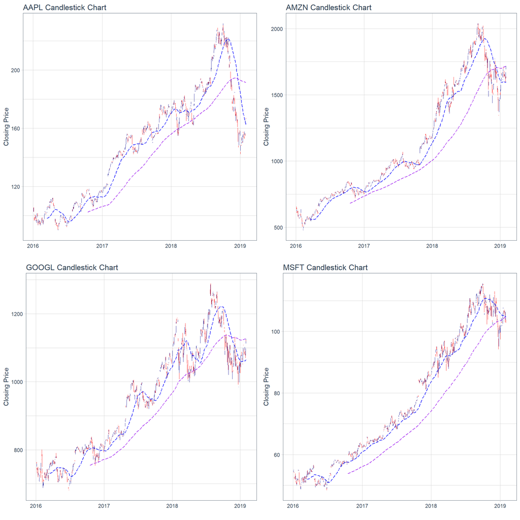

Back to top